# HW#2e8-main

## Apply self-organizing maps (SOM) to the Western US winter seasonal precipitation

```r
set.seed(50) # make reproducible results

# Load winter precipitation data
N = 113 # Time window
wuplocs = matrix(scan("http://civil.colorado.edu/%7Ebalajir/CVEN6833/HWs/HW-2-2018/WesternUS-coords.txt"), ncol=5,byrow=T)
nlocs = dim(wuplocs)[1]
xlats = wuplocs[,3]
xlongs = -wuplocs[,4]

winterprecip = matrix(scan("http://civil.colorado.edu/%7Ebalajir/CVEN6833/HWs/HW-2-2018/western-US-winterprecip-1901-2014.txt"),
                      ncol=nlocs+1,byrow=T)
years = 1901:2013
winterprecip = winterprecip[,2:(nlocs+1)]       #first column is year

avgwinter = colMeans(winterprecip) # remove average at each node to see anomalies

for(i in 1:dim(winterprecip)[1]){
  winterprecip[i,]=winterprecip[i,] - avgwinter # Use precip - mean(point) as original data
}
```

The SOM is performed on the scaled precipitation data. Similarly to the Arctic Melt Onset SOM example, each point is considered the whole observations for a given year. The point will be assigned to a node depending on the distance with the other ones. Each node will be then composed of a mix of “attributes” (years) considered close.

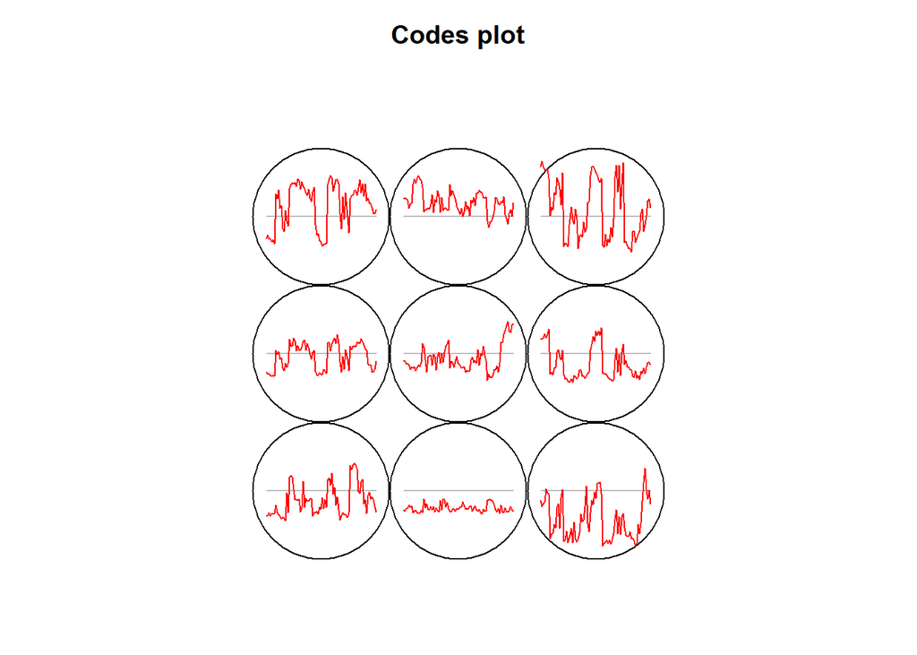

```r
# Self-Organizing Map

som.wp <- som(scale(winterprecip),grid=somgrid(3,3,'rectangular'),
              maxNA.fraction=1)
par(mfrow=c(1,1))

plot(som.wp)                # Codes plot
```

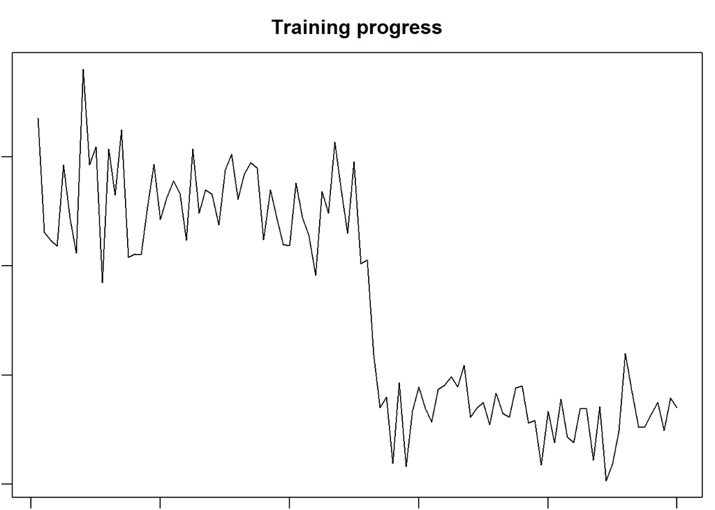

```r
plot(som.wp,type="changes") # training progress
```

```r
print("Number of points at each node:")
```

```
## [1] "Number of points at each node:"
```

```r
table(som.wp$unit.classif) # N datapoints at each node
```

```
##
##  1  2  3  4  5  6  7  8  9
## 14 16  6 13 11 17 13 15  8
```

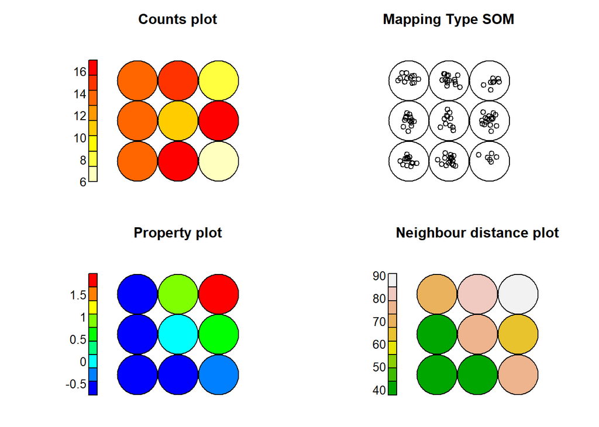

```r
# Plot number of observations in each node
colors <- function(n, alpha = 1) {
  rev(heat.colors(n, alpha))
}
par(mfrow=c(2,2))
plot(som.wp,type = "counts",
     palette.name = colors,
     heatkey = TRUE)

# Mapping Points
plot(som.wp,type = "mapping",
     pchs = 1,main = "Mapping Type SOM")

# Property Plot (scaled precipitation)
coolBlueHotRed <- function(n, alpha = 1) {rainbow(n, end=4/6, alpha=alpha)[n:1]}
plot(som.wp, type = "property",
     property = som.wp$codes[[1]][,1], main=names(som.wp$data)[1],
     palette.name=coolBlueHotRed)

# Mapping Distance
plot(som.wp, type = "dist.neighbours",
     palette.name = terrain.colors)
```

### Composite the precipitation (real values)

We can map now the precipitation at each node as a pattern considering all years at the node. The resulting map would be an averaged precipitation over the years pertaining to the specific node.

```r
# Display composited data into nodes

N = som.wp$grid$xdim * som.wp$grid$ydim # N of nodes

rlist <- list() # average precipitation data for all the years in a node
for(i in 1:N){ # get precipitation at each node
  tmp_df <- winterprecip[which(som.wp$unit.classif==i),]
  rlist[[i]] <- colMeans(tmp_df,na.rm=T)  # get values assoc. to each node
}

winternode = rlist %>% unlist(.) %>%
  {matrix(.,nrow = 81, ncol = N)} # avg precip at node

quantnode = winternode %>% ecdf(.) %>% {.(winternode)} %>%
  matrix(.,nrow = 81,ncol = N) # Transform data in quantiles [0,1]

breaks = c(0,0.25,0.5,0.75,1) # show breaks as quantiles

# breaks = round(as.numeric(quantile(winternode)),2) # show breaks as quantiles

# store data in a matrix
comp = cbind(xlongs,xlats,quantnode)
comp = as.data.frame(comp) # data frame
colnames(comp) = c("xlongs","xlats","N1","N2",
                   "N3","N4","N5","N6","N7","N8","N9")

p_map = function(i){ # plots a ggplot given the column of comp (means at each node)
  ggplot(comp,aes(x = xlongs,y = xlats)) +
  geom_point(aes_string(colour=colnames(comp)[i+2]),size = 5) +
  scale_colour_gradientn(colours = rev(tim.colors(n=4)), breaks = breaks) +
      theme_minimal() +
  borders('state') +
  coord_quickmap(xlim=c(-125,-105),ylim=c(31,50)) +
  theme(legend.position = "none",axis.title.x=element_blank(),
         axis.title.y=element_blank(),legend.title=element_blank(),
        axis.text.x=element_blank(),axis.text.y=element_blank(),
        plot.margin = margin(0.1, 0.1, 0.1, 0.1, "cm"))
}

  # scale_colour_gradient2(low = "#B2182B", mid = "#FDDBC7",
  # high = "#2166AC", midpoint = 0,limits=quantile(winterprecip,c(0,1)) +
  #
  #     scale_color_gradientn(colours = brewer_pal("div",palette="RdBu")(8),
  #                       limits = c(0, 5),na.value = "#2166AC") +

  # scale_color_gradientn(colours = rev(tim.colors(n=8)),
  # limits = quantile(winterprecip,c(0,1)), na.value = "#00008F") +

  # scale_color_gradientn(colours = rev(tim.colors(n=5)), breaks = breaks) +


# quantt = as.character(quantile(winterprecip))
# cols = rev(tim.colors(5))
# names(cols) = quantt
# cols <- c("8" = "red", "4" = "blue", "6" = "darkgreen", "10" = "orange")
```

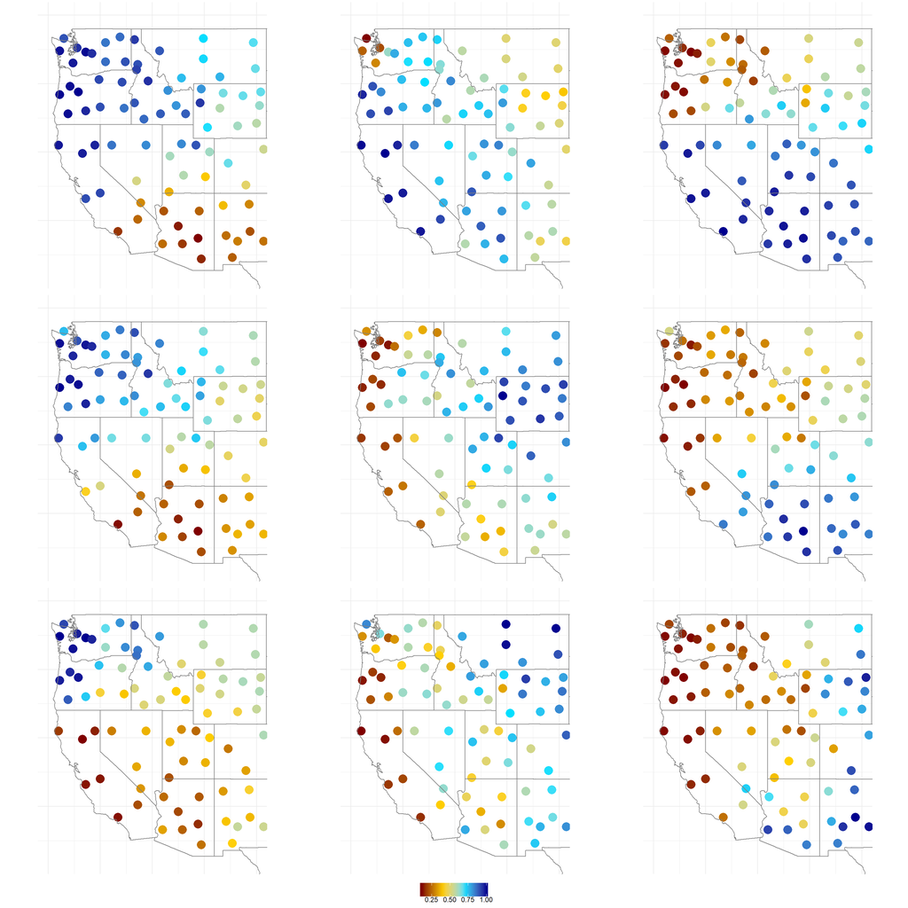

```r
# Plots all the datapoints in a 3x3 matrix
# Order of numbers >> match node number w/ position in ggarrange array
ggarrange(p_map(7), p_map(8), p_map(9), p_map(4), p_map(5), p_map(6), p_map(1), p_map(2), p_map(3), nrow = 3, ncol = 3,
          common.legend = TRUE, legend="bottom")
```

### Composite the pacific SST into each node.

The code below recalls how to plot the SST for a given year

```r
nrows=72 # data import setup
ncols=36
nyrs = 118  # Nov-Mar avg 1901 - 2018

kaplan = # SST data row per NDJFM season format
  readBin("http://civil.colorado.edu/%7Ebalajir/CVEN6833/HWs/HW-2-2018/Kaplan-SST-NDJFM1900-NDJFM2018.r4",what="numeric", n=( nrows * ncols * nyrs), size=4,endian="swap") %>%
  array(data = ., dim=c( nrows*ncols, nyrs ) ) %>% t(.) # 2D and transpose

index1=kaplan[1,]<10 & kaplan[1,] != "NaN"
sstdata=kaplan[,index1] # Drop missing data

xgrid=seq(27.5,382.5,by=5) #Generate grid (27.5,382.5) format
xgrid[xgrid>180]=xgrid[xgrid>180]-360 # -180 180 format
ygrid=seq(-87.5,87.5,by=5)

ylat = sort(ygrid,index.return=TRUE) # Indexing (for drawing if unsorted)
xygrid=expand.grid(x=xgrid,y=ygrid) %>% .[c("y","x")] # Lat - Long grid..

pacgrid=xygrid$y >= -20 & (xygrid$x >= 105 | xygrid$x <= -70) #grid limits
indexpac=index1 & pacgrid # locations on kaplan grid
xygrid1 = xygrid[indexpac,] # coordinates on kaplan grid

sstannavg = kaplan[,indexpac] # Pacific data

xgrid=seq(27.5,382.5,by=5) #Generate grid (27.5,382.5) format
xlong = sort(xgrid,index.return=TRUE)

# Function to plot image plot given the list of years to average data

sstplot = function(i){
zfull = rep(NA,length(xygrid[,1]))
if(length(i)>1){
  zfull[indexpac]=colMeans(sstannavg[i,],na.rm = TRUE)
} else {
    zfull[indexpac]=sstannavg[i,]}
zmat = matrix(zfull,nrow=nrows,ncol=ncols)
zmat = zmat[xlong[["ix"]],] %>% .[,ylat[["ix"]]] # match SST values with sorted rows,columns

  image(xlong[["x"]],ylat[["x"]],zmat, xlim = range(125,280), ylim=range(-30,70),
             asp=1,axes=FALSE, horizontal = TRUE,breaks = c(-2,seq(-0.5,0.5,length.out = 63),2),
        col=tim.colors(n = 64, alpha=1.0))
  graphics::axis(side=1, labels=FALSE)
  graphics::axis(side=2, labels=FALSE)
  contour(xlong[["x"]],ylat[["x"]],zmat,ylim=range(-40,70),add=TRUE,nlev=6,lwd=2)
  map("world2",fill = TRUE,col="darkgray",border="gray",add=TRUE)
}
```

With the function created, we can plot the average over the node years and plot them in a 3 x 3 matrix

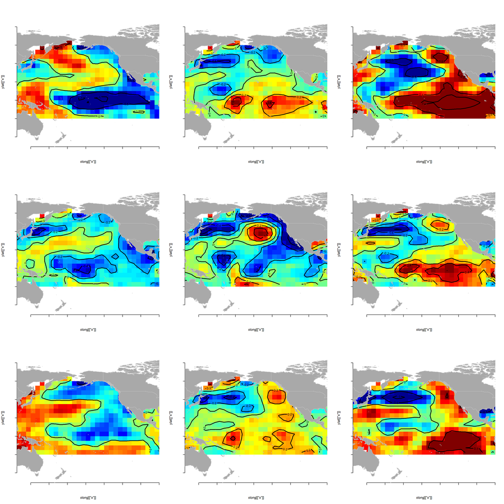

```r
par(mfrow=c(3,3))
for(i in c(7,8,9,4,5,6,1,2,3)){ # match node number w/ mfrow position
  sstplot(which(som.wp$unit.classif==i))
}
```

### Conclusions

The El Niño and La Niña patterns observed in the PCA analysis appear again when using SOM. Similarly, the N-S precipitation dicotomy in the Western US depending on the Pacific SST is clearly reproduced. El Niño leads to dry Northern winters and humid Shouthern ones, and the opposite happens when La Niña occurs.

#### Aux code to source libraries, functions and variables

```r
##
## Source Libraries
##

libr=c("kohonen","ggplot2","fields","magrittr","ggpubr","scales")
options(warn=-1)
suppressPackageStartupMessages(lapply(libr, require,character.only = TRUE))

##
## Source data
##


##
## Source functions
##
```